```python
!pip install opendatasets
```

```
Downloading opendatasets-0.1.22-py3-none-any.whl (15 kB)
```

# MUST HAVE KAGGLE ACCOUNT AND KEY TO ACCESS

{"username":"haythamzaami","key":"e61e0bbb9680b885b96666f48e63e371"}

```python
import opendatasets as od
od.download("https://www.kaggle.com/datasets/aliibrahim10/anime-ratings")
```

```
Please provide your Kaggle credentials to download this dataset. Learn more: http://bit.ly/kaggle-creds
Your Kaggle username: haythamzaami
Your Kaggle Key: ··········
Dataset URL: https://www.kaggle.com/datasets/aliibrahim10/anime-ratings
```

```python
import pandas as pd
anime_df = pd.read_csv("/content/anime-ratings/MALratings.csv")
```

```python
anime_df.head()
```

|  | Title | Genres | Rank | Popularity | Score | Episodes | Episode length | Release Date |
| --- | --- | --- | --- | --- | --- | --- | --- | --- |
| 0 | Kaguya-sama wa Kokurasetai: Ultra Romantic | Comedy,Suspense | 13 | 404 | 8.99 | 12 | 23 min. per ep. | Spring 2022 |
| 1 | 3-gatsu no Lion 2nd Season | Drama,Slice of Life | 14 | 533 | 8.96 | 22 | 25 min. per ep. | Fall 2017 |
| 2 | Gintama Movie 2: Kanketsu-hen - Yorozuya yo Ei... | Action,Comedy,Sci-Fi | 19 | 939 | 8.93 | 1 | 1 hr. 50 min. | NaN |
| 3 | Gintama. | Action,Comedy,Sci-Fi | 12 | 735 | 8.99 | 12 | 24 min. per ep. | Winter 2017 |
| 4 | Koe no Katachi | NaN | 15 | 19 | 8.96 | 1 | 2 hr. 10 min. | NaN |

```python
anime_df.count()
```

|  | 0 |
| --- | --- |
| Title | 20343 |
| Genres | 10016 |
| Rank | 20343 |
| Popularity | 20343 |
| Score | 14019 |
| Episodes | 20343 |
| Episode length | 20343 |
| Release Date | 5087 |

**dtype:** int64

Don't want to deal with NaNs

```python
anime_df.dropna(inplace = True)
anime_df.count()
```

|  | 0 |
| --- | --- |
| Title | 3232 |
| Genres | 3232 |
| Rank | 3232 |
| Popularity | 3232 |
| Score | 3232 |
| Episodes | 3232 |
| Episode length | 3232 |
| Release Date | 3232 |

**dtype:** int64

```python
anime_df.head()
```

|  | Title | Genres | Rank | Popularity | Score | Episodes | Episode length | Release Date |
| --- | --- | --- | --- | --- | --- | --- | --- | --- |
| 0 | Kaguya-sama wa Kokurasetai: Ultra Romantic | Comedy,Suspense | 13 | 404 | 8.99 | 12 | 23 min. per ep. | Spring 2022 |
| 1 | 3-gatsu no Lion 2nd Season | Drama,Slice of Life | 14 | 533 | 8.96 | 22 | 25 min. per ep. | Fall 2017 |
| 3 | Gintama. | Action,Comedy,Sci-Fi | 12 | 735 | 8.99 | 12 | 24 min. per ep. | Winter 2017 |
| 6 | Code Geass: Hangyaku no Lelouch | Action,Drama,Sci-Fi | 50 | 17 | 8.70 | 25 | 24 min. per ep. | Fall 2006 |
| 7 | Gintama | Action,Comedy,Sci-Fi | 16 | 127 | 8.95 | 201 | 24 min. per ep. | Spring 2006 |

# Don't want movies/specials/OVAs get rid of 1 episode animes

```python
anime_df['Episodes'] = pd.to_numeric(anime_df['Episodes'], errors='coerce')
anime_df = anime_df[anime_df['Episodes'] > 1]
```

```python
anime_df.head(20)
```

|  | Title | Genres | Rank | Popularity | Score | Episodes | Episode length | Release Date |
| --- | --- | --- | --- | --- | --- | --- | --- | --- |
| 0 | Kaguya-sama wa Kokurasetai: Ultra Romantic | Comedy,Suspense | 13 | 404 | 8.99 | 12.0 | 23 min. per ep. | Spring 2022 |
| 1 | 3-gatsu no Lion 2nd Season | Drama,Slice of Life | 14 | 533 | 8.96 | 22.0 | 25 min. per ep. | Fall 2017 |
| 3 | Gintama. | Action,Comedy,Sci-Fi | 12 | 735 | 8.99 | 12.0 | 24 min. per ep. | Winter 2017 |
| 6 | Code Geass: Hangyaku no Lelouch | Action,Drama,Sci-Fi | 50 | 17 | 8.70 | 25.0 | 24 min. per ep. | Fall 2006 |
| 7 | Gintama | Action,Comedy,Sci-Fi | 16 | 127 | 8.95 | 201.0 | 24 min. per ep. | Spring 2006 |
| 10 | Vinland Saga | Action,Adventure,Drama | 43 | 102 | 8.73 | 24.0 | 24 min. per ep. | Summer 2019 |
| 14 | 86 Part 2 | Action,Drama,Sci-Fi | 44 | 647 | 8.72 | 12.0 | 23 min. per ep. | Fall 2021 |
| 15 | Mushishi Zoku Shou 2nd Season | Adventure,Fantasy,Mystery,Slice of Life,Supern... | 41 | 827 | 8.74 | 10.0 | 23 min. per ep. | Fall 2014 |
| 18 | Clannad: After Story | Drama,Romance,Supernatural | 18 | 105 | 8.94 | 24.0 | 24 min. per ep. | Fall 2008 |
| 19 | Mushishi Zoku Shou | Adventure,Fantasy,Mystery,Slice of Life,Supern... | 47 | 731 | 8.71 | 10.0 | 24 min. per ep. | Spring 2014 |
| 20 | Zoku Natsume Yuujinchou | Drama,Slice of Life,Supernatural | 94 | 857 | 8.55 | 13.0 | 24 min. per ep. | Winter 2009 |
| 22 | Ashita no Joe 2 | Action,Drama,Slice of Life,Sports | 46 | 2917 | 8.71 | 47.0 | 24 min. per ep. | Fall 1980 |
| 23 | Sora yori mo Tooi Basho | Adventure,Comedy,Drama | 95 | 416 | 8.54 | 13.0 | 23 min. per ep. | Winter 2018 |
| 24 | Yakusoku no Neverland | Mystery,Sci-Fi,Suspense | 96 | 39 | 8.54 | 12.0 | 22 min. per ep. | Winter 2019 |
| 25 | Koukaku Kidoutai: Stand Alone Complex | Action,Sci-Fi | 148 | 504 | 8.43 | 26.0 | 25 min. per ep. | Fall 2002 |
| 26 | Code Geass: Hangyaku no Lelouch R2 | Action,Drama,Sci-Fi | 20 | 47 | 8.91 | 25.0 | 24 min. per ep. | Spring 2008 |
| 27 | Major S6 | Comedy,Drama,Sports | 199 | 2452 | 8.34 | 25.0 | 24 min. per ep. | Spring 2010 |
| 28 | Mononoke | Fantasy,Horror,Mystery,Supernatural | 149 | 710 | 8.43 | 12.0 | 22 min. per ep. | Summer 2007 |
| 29 | Kiseijuu: Sei no Kakuritsu | Action,Horror,Sci-Fi | 196 | 41 | 8.35 | 24.0 | 23 min. per ep. | Fall 2014 |
| 31 | Yuru Camp△ Season 2 | Comedy,Slice of Life | 97 | 1073 | 8.54 | 13.0 | 23 min. per ep. | Winter 2021 |

# What are the top 10 most popular anime series in the dataset?

```python
anime_df.sort_values(by='Popularity', ascending=True).head(10)
```

|  | Title | Genres | Rank | Popularity | Score | Episodes | Episode length | Release Date |
| --- | --- | --- | --- | --- | --- | --- | --- | --- |
| 20240 | Shingeki no Kyojin | Action,Drama | 104 | 1 | 8.53 | 25.0 | 24 min. per ep. | Spring 2013 |
| 20261 | Death Note | Supernatural,Suspense | 74 | 2 | 8.62 | 37.0 | 23 min. per ep. | Fall 2006 |
| 20328 | Fullmetal Alchemist: Brotherhood | Action,Adventure,Drama,Fantasy | 1 | 3 | 9.14 | 64.0 | 24 min. per ep. | Spring 2009 |
| 20241 | One Punch Man | Action,Comedy | 114 | 4 | 8.51 | 12.0 | 24 min. per ep. | Fall 2015 |
| 17826 | Sword Art Online | Action,Adventure,Fantasy,Romance | 2957 | 5 | 7.20 | 25.0 | 23 min. per ep. | Summer 2012 |
| 19626 | Tokyo Ghoul | Action,Fantasy,Horror | 879 | 7 | 7.80 | 12.0 | 24 min. per ep. | Summer 2014 |
| 19827 | Naruto | Action,Adventure,Fantasy | 603 | 8 | 7.97 | 220.0 | 23 min. per ep. | Fall 2002 |
| 20245 | Kimetsu no Yaiba | Action,Fantasy | 91 | 9 | 8.55 | 26.0 | 23 min. per ep. | Spring 2019 |
| 20307 | Hunter x Hunter (2011) | Action,Adventure,Fantasy | 8 | 10 | 9.05 | 148.0 | 23 min. per ep. | Fall 2011 |
| 20229 | Shingeki no Kyojin Season 2 | Action,Drama | 117 | 12 | 8.50 | 12.0 | 24 min. per ep. | Spring 2017 |

# Is there a relationship between rating and popularity? (LOWER POPULARITY IS A GOOD THING, MEANS ITS MORE POPULAR)

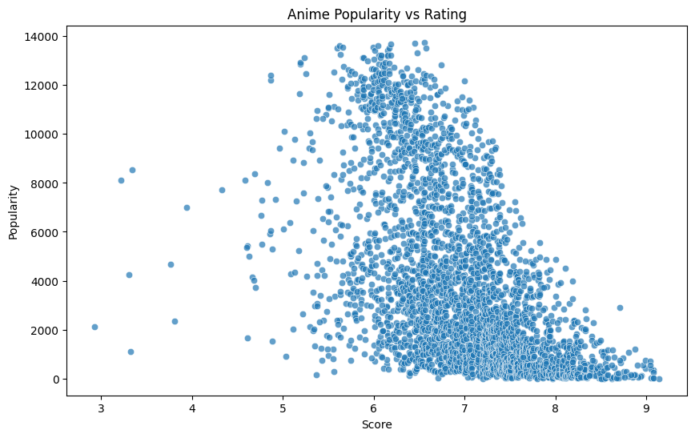

```python
import matplotlib.pyplot as plt
import seaborn as sns
plt.figure(figsize=(10, 6))
sns.scatterplot(x='Score', y='Popularity', data=anime_df, alpha=0.7)
plt.title('Anime Popularity vs Rating')
```

# More popular anime tend to be higher rated, with a heavy presence around 7.5 and the popularity being in the top ~1000

```python
print(anime_df.columns)
```

```
Index(['Title', 'Genres', 'Rank', 'Popularity', 'Score', 'Episodes',
       'Episode length', 'Release Date'],
      dtype='object')
```

# Anime became really popular in 2020. Did studios take advantage of that and start producing more animes since 2020? And if so, how well rated were they?

```python
anime_YEAR_df = anime_df.copy()
anime_YEAR_df["Release Date"] = anime_YEAR_df["Release Date"].str[-4:].astype(int)
```

```python
anime_YEAR_df
```

|  | Title | Genres | Rank | Popularity | Score | Episodes | Episode length | Release Date |
| --- | --- | --- | --- | --- | --- | --- | --- | --- |
| 0 | Kaguya-sama wa Kokurasetai: Ultra Romantic | Comedy,Suspense | 13 | 404 | 8.99 | 12.0 | 23 min. per ep. | 2022 |
| 1 | 3-gatsu no Lion 2nd Season | Drama,Slice of Life | 14 | 533 | 8.96 | 22.0 | 25 min. per ep. | 2017 |
| 3 | Gintama. | Action,Comedy,Sci-Fi | 12 | 735 | 8.99 | 12.0 | 24 min. per ep. | 2017 |
| 6 | Code Geass: Hangyaku no Lelouch | Action,Drama,Sci-Fi | 50 | 17 | 8.70 | 25.0 | 24 min. per ep. | 2006 |
| 7 | Gintama | Action,Comedy,Sci-Fi | 16 | 127 | 8.95 | 201.0 | 24 min. per ep. | 2006 |
| ... | ... | ... | ... | ... | ... | ... | ... | ... |
| 20325 | Shingeki no Kyojin Season 3 Part 2 | Action,Drama | 3 | 31 | 9.08 | 10.0 | 23 min. per ep. | 2019 |
| 20328 | Fullmetal Alchemist: Brotherhood | Action,Adventure,Drama,Fantasy | 1 | 3 | 9.14 | 64.0 | 24 min. per ep. | 2009 |
| 20332 | Kakutou Bijin Wulong: Rebirth | Action,Comedy | 4366 | 8397 | 6.89 | 25.0 | 25 min. per ep. | 2006 |
| 20338 | Steins;Gate | Drama,Sci-Fi,Suspense | 4 | 13 | 9.08 | 24.0 | 24 min. per ep. | 2011 |
| 20339 | High Score | Comedy,Slice of Life | 10527 | 6095 | 5.58 | 8.0 | 3 min. per ep. | 2011 |

3210 rows × 8 columns

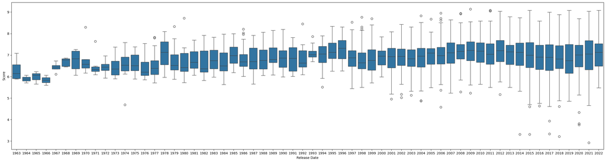

```python
plt.figure(figsize=(32, 8))
sns.boxplot(x='Release Date', y='Score', data=anime_YEAR_df)
```

# Ratings don't have a spike, meaning quality of anime didn't change much in 2020. But still, we're there more anime released in 2020 as compared to other years?

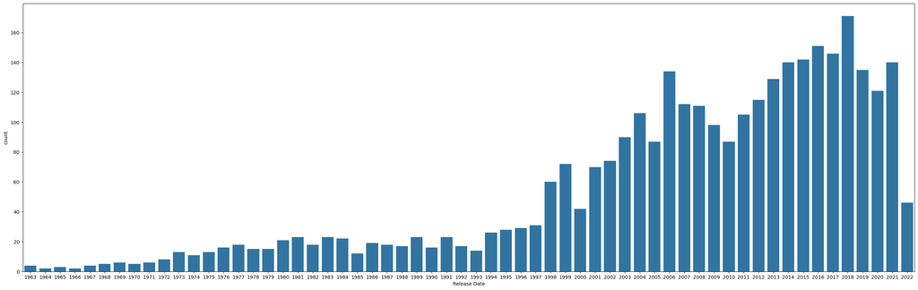

```python
anime_YEAR_df["Release Date"].value_counts()

yr_counts = anime_YEAR_df["Release Date"].value_counts().reset_index()
yr_counts.columns = ['Release Date', 'count']

plt.figure(figsize=(33, 10))
sns.barplot(x='Release Date', y='count', data=yr_counts)
```

# 2018 had highest count of anime released, no relation for covid and anime released

# How does episode count correlate with an anime's score? Do viewers prefer shorter or longer series?

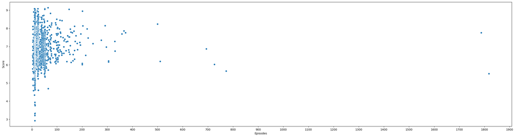

```python
plt.figure(figsize=(32, 8))
sns.scatterplot(x='Episodes', y='Score', data=anime_YEAR_df)
plt.locator_params(axis='x', nbins=20)
```

```python
anime_YEAR_df[(anime_YEAR_df["Release Date"] == 1999) & (anime_YEAR_df["Episodes"] >= 200)]
```

|  | Title | Genres | Rank | Popularity | Score | Episodes | Episode length | Release Date |
| --- | --- | --- | --- | --- | --- | --- | --- | --- |

# Hm seems like One Piece is not in this data set. Weird

```python
anime_YEAR_df[['Episodes', 'Score']].corr()
```

|  | Episodes | Score |
| --- | --- | --- |
| Episodes | 1.000000 | 0.011592 |
| Score | 0.011592 | 1.000000 |

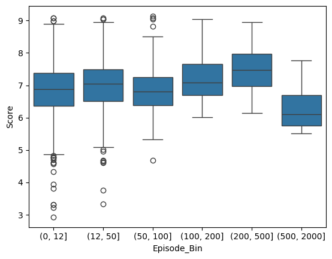

```python
anime_YEAR_df['Episode_Bin'] = pd.cut(anime_YEAR_df['Episodes'], bins=[0, 12, 50, 100, 200, 500, 2000])
sns.boxplot(x='Episode_Bin', y='Score', data=anime_YEAR_df)
```

# **Very small** positive correlation for length of anime vs rating

# Has the average number of episodes per anime changed over the years? (As in anime that was released in a given year, how many episodes did it finish with? *NOT* how many episdoes each anime produced in the year)

```python
ep_per_year = anime_YEAR_df.groupby('Release Date')['Episodes'].mean()
ep_per_year
```

| Release Date | Episodes |
| --- | --- |
| 1963 | 92.000000 |
| 1964 | 62.000000 |
| 1965 | 66.666667 |
| 1966 | 30.500000 |
| 1967 | 49.250000 |
| 1968 | 74.800000 |
| 1969 | 56.500000 |
| 1970 | 85.200000 |
| 1971 | 34.666667 |
| 1972 | 55.375000 |
| 1973 | 40.076923 |
| 1974 | 50.454545 |
| 1975 | 46.000000 |
| 1976 | 57.437500 |
| 1977 | 44.833333 |
| 1978 | 62.000000 |
| 1979 | 158.266667 |
| 1980 | 48.047619 |
| 1981 | 91.521739 |
| 1982 | 43.333333 |
| 1983 | 54.086957 |
| 1984 | 36.636364 |
| 1985 | 92.500000 |
| 1986 | 50.947368 |
| 1987 | 89.166667 |
| 1988 | 63.294118 |
| 1989 | 68.391304 |
| 1990 | 55.187500 |
| 1991 | 48.304348 |
| 1992 | 66.117647 |
| 1993 | 55.142857 |
| 1994 | 137.653846 |
| 1995 | 42.428571 |
| 1996 | 53.689655 |
| 1997 | 42.258065 |
| 1998 | 25.366667 |
| 1999 | 27.458333 |
| 2000 | 40.642857 |
| 2001 | 26.885714 |
| 2002 | 38.905405 |
| 2003 | 27.177778 |
| 2004 | 31.594340 |
| 2005 | 24.275862 |
| 2006 | 27.641791 |
| 2007 | 25.750000 |
| 2008 | 20.909910 |
| 2009 | 27.683673 |
| 2010 | 19.586207 |
| 2011 | 21.876190 |
| 2012 | 20.573913 |
| 2013 | 17.627907 |
| 2014 | 19.428571 |
| 2015 | 16.908451 |
| 2016 | 17.556291 |
| 2017 | 16.513699 |
| 2018 | 17.304094 |
| 2019 | 15.725926 |
| 2020 | 17.000000 |
| 2021 | 14.178571 |
| 2022 | 12.869565 |

**dtype:** float64

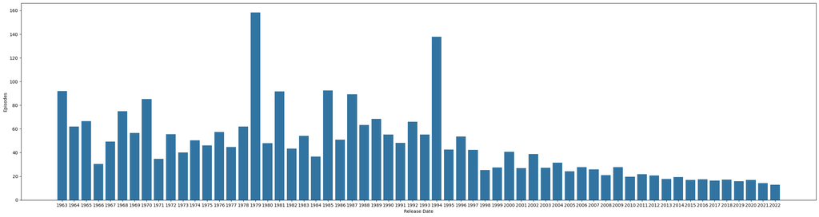

```python
plt.figure(figsize=(32, 8))
ep_per_year_df = ep_per_year.reset_index()
sns.barplot(x='Release Date', y='Episodes', data=ep_per_year_df)
plt.locator_params(axis='x', nbins=20)
```

# 1994 and 1979 were years that had animes produce the most episodes

# Makes sense as we get closer to 2025 the bars get lower, anime recently released tend to produce an episode a week for ~6-12 weeks

```python
print(anime_df.dtypes)
```

```
Title              object
Genres             object
Rank               object
Popularity          int64
Score             float64
Episodes          float64
Episode length     object
Release Date       object
dtype: object
```

# What genres have the highest rating?

```python
len(anime_df["Genres"].unique())
```

```
547
```

# Too many unique combinations of genres, hard to visualize

```python
genre_avg_scores = anime_df.groupby("Genres")["Score"].mean().sort_values(ascending=False)
genre_avg_scores.head(30)
```

| Genres | Score |
| --- | --- |
| Comedy,Suspense | 8.990000 |
| Drama,Sci-Fi,Suspense | 8.800000 |
| Adventure,Fantasy,Mystery,Slice of Life,Supernatural | 8.706667 |
| Adventure,Drama,Fantasy,Mystery,Sci-Fi | 8.680000 |
| Comedy,Mystery,Romance | 8.580000 |
| Drama,Fantasy,Ecchi | 8.560000 |
| Mystery,Sci-Fi,Suspense | 8.540000 |
| Drama,Slice of Life,Supernatural | 8.520000 |
| Action,Drama,Slice of Life,Sports | 8.500000 |
| Adventure,Drama,Supernatural | 8.390000 |
| Drama,Fantasy,Suspense | 8.370000 |
| Action,Horror,Sci-Fi | 8.350000 |
| Action,Avant Garde,Drama,Sci-Fi | 8.340000 |
| Action,Adventure,Romance | 8.330000 |
| Drama,Horror,Mystery,Sci-Fi,Supernatural | 8.310000 |
| Comedy,Drama,Romance,Sports | 8.305000 |
| Boys Love,Slice of Life | 8.280000 |
| Action,Adventure,Drama,Supernatural | 8.270000 |
| Drama,Sci-Fi,Sports | 8.210000 |
| Adventure,Mystery,Sci-Fi,Slice of Life | 8.190000 |
| Comedy,Drama,Fantasy,Mystery | 8.180000 |
| Comedy,Mystery,Romance,Supernatural | 8.175000 |
| Drama,Supernatural,Suspense | 8.170000 |
| Action,Drama,Fantasy,Mystery | 8.165000 |
| Adventure,Mystery,Romance,Sci-Fi | 8.150000 |
| Drama,Mystery,Sci-Fi,Supernatural,Suspense | 8.150000 |
| Comedy,Mystery,Supernatural,Ecchi | 8.130000 |
| Fantasy,Sci-Fi,Slice of Life | 8.120000 |
| Mystery,Slice of Life | 8.100000 |
| Adventure,Mystery,Sci-Fi | 8.100000 |

**dtype:** float64

# (Comedy, Suspense) as a group are the highest rated. Genres aren't a list in this dataset, so can't search by just one element of a set.

# **Closing Thoughts**

## I was able to learn a lot about data manipulation/visualization with Pandas.

## Although there are some trends in the data, certain correlations I would've thought would be apparent were not. Take for example the 2020 Animes.

# **Questions**

### What are the top 10 most popular anime series in the dataset? (Done)

### Is there a relationship between rating and popularity? (Done)

### Anime became really popular in 2020. Did studios take advantage of that and start producing more anime in 2020? And if so, how well rated were they? (Done)

### How does episode count correlate with an anime's score? Do viewers prefer shorter or longer series? (Done)

### Has the average number of episodes per anime changed over the years? (As in anime that was released in a given year, how many episodes did it finish with? *NOT* how many episodes each anime produced in the year) (Done)

### What genres have the highest rating? (Done)